# introduction

# Preliminaries

Load the required libraries.

```r
library(llperm)
library(phyloseq)
library(ggplot2)
```

## Load the data set

Load the data set. We have three data frames: OTU table, taxonomy table, and person metadata.

```r
fn.sequence <- system.file("extdata", "VEGA_sequences.txt", package = "llperm")
fn.taxonomy <- system.file("extdata", "VEGA_taxonomy.txt", package = "llperm")
fn.metadata <- system.file("extdata", "VEGA metadata.txt", package = "llperm")

otu.table    <- t(read.table(fn.sequence, sep="\t", header=T, row.names=1))
otu.taxonomy <- read.table(fn.taxonomy, sep="\t", header=T, row.names=1, stringsAsFactors=T)
otu.metadata <- read.table(fn.metadata, sep="\t", header=T, row.names=1)

# Set the reference level to the most common category
otu.metadata <- with(otu.metadata, data.frame(
  Age = Age,
  UrbanizationLevel = Urbanization_level,
  Gender = relevel(factor(Gender), "Female"),
  Diet = relevel(factor(group), "meateater"),
  # Low education has only 4 observations
  Education = factor(education, c("", "High", "Low", "Middle"), labels=c("MidLow", "High", "MidLow", "MidLow")),
  PetAnimals = relevel(factor(Pet_animals_at_home), "Yes"),
  TravelToSE = relevel(factor(Travel.to.Southern..or.Eastern.Europe.in.the.past.6.months), "No"),
  row.names = rownames(otu.metadata)))

# Take only persons with both microbiome information and demographic information
sample.ids <- intersect(rownames(otu.table), rownames(otu.metadata))
otu.table <- otu.table[sample.ids,]
otu.metadata <- otu.metadata[sample.ids,]
```

Having the data inside a single phyloseq object allows easier data manipulation:

```r
ps <- phyloseq(otu_table(otu.table, taxa_are_rows=FALSE),
               sample_data(otu.metadata),
               tax_table(as.matrix(otu.taxonomy)))
```

## Filtering and transforming data for analysis

We limit our analysis to the VEGA study which has 4 diet groups and 149 persons x 6385 OTUs:

```r
ps = subset_samples(ps, Diet %in% c("meateater", "fisheater", "vegetarian", "vegan"))
ps
```

```
#> phyloseq-class experiment-level object
#> otu_table()   OTU Table:         [ 6385 taxa and 149 samples ]
#> sample_data() Sample Data:       [ 149 samples by 7 sample variables ]
#> tax_table()   Taxonomy Table:    [ 6385 taxa by 6 taxonomic ranks ]
```

We also filter those taxa in the full OTU table with less than 10% prevalence, leaving us with 595 OTUs:

```r
otu.prevalence <- colSums(otu_table(ps) > 1) / nsamples(ps)
otu.keep       <- taxa_names(ps)[otu.prevalence >= 0.10] # #0.10
ps<- prune_taxa(otu.keep, ps)
ps
```

```
#> phyloseq-class experiment-level object
#> otu_table()   OTU Table:         [ 595 taxa and 149 samples ]
#> sample_data() Sample Data:       [ 149 samples by 7 sample variables ]
#> tax_table()   Taxonomy Table:    [ 595 taxa by 6 taxonomic ranks ]
```

To analyze the data with a simple linear model we use the relative abundance transformation. Normalize the row counts by the total count per row:

```r
# Relative abundance and Log-transformed absolute abundance
ps.rel <- transform_sample_counts(ps, function(x){log((1 + x) / sum(1 + x))})
```

## Data frames

Add a random diet group to test the results when there is ‘no signal’

```r
set.seed(42)
DietRandom <- sample_data(ps)$Diet[sample(1:nsamples(ps))]
```

### OTU counts (otu.counts)

Data frame of counts]

```r
otu.counts   <- cbind(otu_table(ps), sample_data(ps))
otu.counts$DietRandom <- DietRandom # Random permutation of diet group labels
otu.counts$library_size <- rowSums(otu_table(ps))
```

Visualize the ‘ASV159’ as an example taxa:

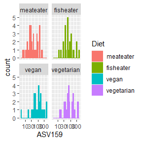

```r
p <- ggplot(otu.counts, aes(x=ASV159, color=Diet, fill=Diet)) + geom_histogram(bins=30) + facet_wrap(~Diet) + scale_x_continuous(trans='log10')
print(p)
```

### OTU relative abundances (otu.relative)

Data frame of relative abundances

```r
otu.relative    <- cbind(otu_table(ps.rel), sample_data(ps.rel))
otu.relative$DietRandom <- DietRandom # Random permutation of diet group labels
```

Visualize the ‘ASV159’ as an example taxa:

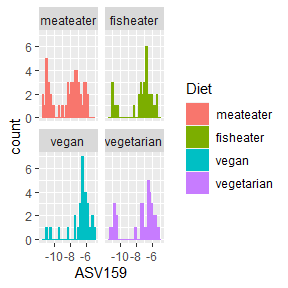

```r
p <- ggplot(otu.relative, aes(x=ASV159, color=Diet, fill=Diet)) + geom_histogram(bins=30) + facet_wrap(~Diet)
print(p)
```

# Experiments

Run the experiments over these OTUs:

```r
taxas <- taxa_names(ps)
```

```r
#Faster alternative, only use 100 OTUs:
#taxas <- sample(taxas, 100, replace=F)
```

## Original PRR-test implementation

The original implementation of glmperm does not support factors with several levels, so we create a new binary indicator vegetarian or vegan = Y/N

```r
# Binary vegetarian Y/N
otu.relative$DietVeg <- factor(otu.relative$Diet,
                               levels=c("meateater", "fisheater", "vegan", "vegetarian"),
                               labels=c("no", "no", "yes", "yes"))
otu.relative$DietVeg <- as.numeric(otu.relative$DietVeg == "yes")

# Binary vegetarian Y/N from randomly permuted diet
otu.relative$DietVegRandom <- factor(otu.relative$DietRandom,
                                  levels=c("meateater", "fisheater", "vegan", "vegetarian"),
                                  labels=c("no", "no", "yes", "yes"))
otu.relative$DietVegRandom <- as.numeric(otu.relative$DietVegRandom == "yes")
```

### Linear model on relative abundances (Diet)

Apply the original glmperm implementation to the example OTU:

```r
fit <- prr.test(ASV159 ~ DietVeg + Age + UrbanizationLevel + Gender + Education + PetAnimals + TravelToSE, var = "DietVeg", data=otu.relative, nrep=1000)
summary(fit)
```

```
#>
#>
#>     Permutation of Regressor Residuals Test:
#>
#>
#> Call:
#>  prr.test(formula = ASV159 ~ DietVeg + Age + UrbanizationLevel +      Gender + Education + PetAnimals + TravelToSE, var = "DietVeg",      data = otu.relative, nrep = 1000)
#>
#> number of observations used:  149
#>
#> null hypothesis: regression coefficient of covariate DietVeg = 0
#> observed Likelihood Ratio Test Statistics:  8.6979
#>
#>     -----------------------------------------
#>     Results based on chi-squared distribution
#>     -----------------------------------------
#>
#> observed p-value: 0.0032
#>
#>     ---------------------------------------------------
#>     Results based on permutation of regressor residuals
#>     ---------------------------------------------------
#>
#> permutation p-value for simulated p-values <= observed p-value: 0.005 (Std.err: 0.0022)
#>
#> permutation p-value for simulated p-values <= 1.005 observed p-value: 0.005 (Std.err: 0.0022)
#>
#> permutation p-value for simulated p-values <= 1.01 observed p-value: 0.005 (Std.err: 0.0022)
#>
#> permutation p-value for simulated p-values <= 1.02 observed p-value: 0.005 (Std.err: 0.0022)
#>
#> permutation p-value for simulated p-values <= 1.04 observed p-value: 0.005 (Std.err: 0.0022)
```

Apply the original glmperm implementation all OTUs, saving the likelihood and PRR test based p-values for Diet and DietRandom:

```r
pvals.data.obs  <- c()
pvals.null.obs  <- c()
pvals.data.sim  <- c()
pvals.null.sim  <- c()
for(taxa in taxas) {
  #print(taxa)
  eq1 <- as.formula(sprintf("%s ~ DietVeg + Age + UrbanizationLevel + Gender + Education + PetAnimals + TravelToSE", taxa))
  eq2 <- as.formula(sprintf("%s ~ DietVegRandom + Age + UrbanizationLevel + Gender + Education + PetAnimals + TravelToSE", taxa))
  fit1 <- prr.test(eq1, data=otu.relative, var = "DietVeg", nrep=100)
  fit2 <- prr.test(eq2, data=otu.relative, var = "DietVegRandom", nrep=100)
  pvals.data.obs[taxa]  <- fit1$p.value.obs
  pvals.null.obs[taxa]  <- fit2$p.value.obs
  pvals.data.sim[taxa]  <- fit1$p.value.perm$p0
  pvals.null.sim[taxa]  <- fit2$p.value.perm$p0
}
```

Likelihood:

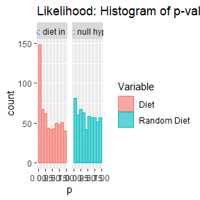

```r
df <- rbind(data.frame(experiment='p-values: diet in data set', p=pvals.data.obs, Variable="Diet"),
            data.frame(experiment='p-values: null hypothesis', p=pvals.null.obs, Variable="Random Diet"))
ggplot(df, aes(x=p, color=Variable, fill=Variable)) + geom_histogram(alpha=0.6, breaks = seq(0,1,0.1)) + facet_wrap(~experiment) +
  ggtitle("Likelihood: Histogram of p-values")
```

PRR test:

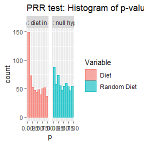

```r
df <- rbind(data.frame(experiment='p-values: diet in data set', p=pvals.data.sim, Variable="Diet"),
            data.frame(experiment='p-values: null hypothesis', p=pvals.null.sim, Variable="Random Diet"))
ggplot(df, aes(x=p, color=Variable, fill=Variable)) + geom_histogram(alpha=0.6, breaks = seq(0,1,0.1)) + facet_wrap(~experiment) +
  ggtitle("PRR test: Histogram of p-values")
```

## New PRR-test implementation for any model

### Linear model on relative abundances (Diet)

Apply the new glmperm implementation to the example OTU:

```r
prr.test.new(ASV159 ~ Diet + Age + UrbanizationLevel + Gender + Education + PetAnimals + TravelToSE,
          data=otu.relative, test.var = "Diet", n.rep=1000, method="glm.fit.fixed", family=gaussian())
```

```
#> $p.value.obs
#> [1] 0.0009080735
#>
#> $p.value.sim
#> [1] 0.002
```

Apply the new glmperm implementation all OTUs, saving the likelihood and PRR test based p-values for Diet and DietRandom:

```r
pvals.data.obs  <- c()
pvals.null.obs  <- c()
pvals.data.sim  <- c()
pvals.null.sim  <- c()
for(taxa in taxas) {
  #print(taxa)
  eq1 <- as.formula(sprintf("%s ~ Diet + Age + UrbanizationLevel + Gender + Education + PetAnimals + TravelToSE", taxa))
  eq2 <- as.formula(sprintf("%s ~ DietRandom + Age + UrbanizationLevel + Gender + Education + PetAnimals + TravelToSE", taxa))
  fit1 <- prr.test.new(eq1, data=otu.relative, test.var = "Diet", n.rep=100, method="glm.fit.fixed", family=gaussian())
  fit2 <- prr.test.new(eq2, data=otu.relative, test.var = "DietRandom", n.rep=100, method="glm.fit.fixed", family=gaussian())
  pvals.data.obs[taxa]  <- fit1$p.value.obs
  pvals.null.obs[taxa]  <- fit2$p.value.obs
  pvals.data.sim[taxa]  <- fit1$p.value.sim
  pvals.null.sim[taxa]  <- fit2$p.value.sim
}
```

Likelihood:

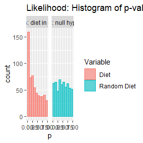

```r
df <- rbind(data.frame(experiment='p-values: diet in data set', p=pvals.data.obs, Variable="Diet"),
            data.frame(experiment='p-values: null hypothesis', p=pvals.null.obs, Variable="Random Diet"))
ggplot(df, aes(x=p, color=Variable, fill=Variable)) + geom_histogram(alpha=0.6, breaks = seq(0,1,0.1)) + facet_wrap(~experiment) +
  ggtitle("Likelihood: Histogram of p-values")
```

PRR test:

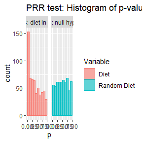

```r
df <- rbind(data.frame(experiment='p-values: diet in data set', p=pvals.data.sim, Variable="Diet"),
            data.frame(experiment='p-values: null hypothesis', p=pvals.null.sim, Variable="Random Diet"))
ggplot(df, aes(x=p, color=Variable, fill=Variable)) + geom_histogram(alpha=0.6, breaks = seq(0,1,0.1)) + facet_wrap(~experiment) +
  ggtitle("PRR test: Histogram of p-values")
```

### Poisson model on counts (Diet)

Apply the new glmperm implementation to the example OTU:

```r
prr.test.new(ASV159 ~ Diet + Age + UrbanizationLevel + Gender + Education + PetAnimals + TravelToSE + offset(log(library_size)),
          data=otu.counts, test.var = "Diet", n.rep=1000, method="glm.fit.fixed", family=poisson())
```

```
#> $p.value.obs
#> [1] 1.536826e-296
#>
#> $p.value.sim
#> [1] 0
```

Apply the new glmperm implementation all OTUs, saving the likelihood and PRR test based p-values for Diet and DietRandom:

```r
set.seed(42)

pvals.data.obs  <- c()
pvals.null.obs  <- c()
pvals.data.sim  <- c()
pvals.null.sim  <- c()
for(taxa in taxas) {
  #print(taxa)
  eq1 <- as.formula(sprintf("%s ~ Diet + Age + UrbanizationLevel + Gender + Education + PetAnimals + TravelToSE + offset(log(library_size))", taxa))
  eq2 <- as.formula(sprintf("%s ~ DietRandom + Age + UrbanizationLevel + Gender + Education + PetAnimals + TravelToSE + offset(log(library_size))", taxa))
  fit1 <- prr.test.new(eq1, data=otu.counts, test.var = "Diet", n.rep=100, method="glm.fit.fixed", family=poisson())
  fit2 <- prr.test.new(eq2, data=otu.counts, test.var = "DietRandom", n.rep=100, method="glm.fit.fixed", family=poisson())
  pvals.data.obs[taxa]  <- fit1$p.value.obs
  pvals.null.obs[taxa]  <- fit2$p.value.obs
  pvals.data.sim[taxa]  <- fit1$p.value.sim
  pvals.null.sim[taxa]  <- fit2$p.value.sim
}
```

Likelihood:

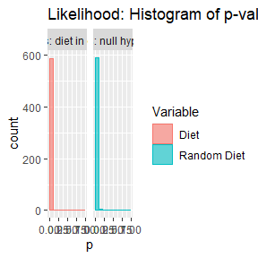

```r
df <- rbind(data.frame(experiment='p-values: diet in data set', p=pvals.data.obs, Variable="Diet"),
            data.frame(experiment='p-values: null hypothesis', p=pvals.null.obs, Variable="Random Diet"))
ggplot(df, aes(x=p, color=Variable, fill=Variable)) + geom_histogram(alpha=0.6, breaks = seq(0,1,0.1)) + facet_wrap(~experiment) +
  ggtitle("Likelihood: Histogram of p-values")
```

PRR test:

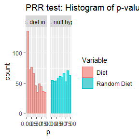

```r
df <- rbind(data.frame(experiment='p-values: diet in data set', p=pvals.data.sim, Variable="Diet"),
            data.frame(experiment='p-values: null hypothesis', p=pvals.null.sim, Variable="Random Diet"))
ggplot(df, aes(x=p, color=Variable, fill=Variable)) + geom_histogram(alpha=0.6, breaks = seq(0,1,0.1)) + facet_wrap(~experiment) +
  ggtitle("PRR test: Histogram of p-values")
```

### Binomial model on counts (Diet)

Apply the new glmperm implementation to the example OTU:

```r
prr.test.new(cbind(ASV159, library_size - ASV159) ~ Diet + Age + UrbanizationLevel + Gender + Education + PetAnimals + TravelToSE + offset(log(library_size)),
          data=otu.counts, test.var = "Diet", n.rep=1000, method="glm.fit.fixed", family=binomial())
```

```
#> $p.value.obs
#> [1] 1.027545e-266
#>
#> $p.value.sim
#> [1] 0
```

Apply the new glmperm implementation all OTUs, saving the likelihood and PRR test based p-values for Diet and DietRandom:

```r
set.seed(42)

pvals.data.obs  <- c()
pvals.null.obs  <- c()
pvals.data.sim  <- c()
pvals.null.sim  <- c()
for(taxa in taxas) {
  #print(taxa)
  eq1 <- as.formula(sprintf("cbind(%s, library_size - %s) ~ Diet + Age + UrbanizationLevel + Gender + Education + PetAnimals + TravelToSE", taxa, taxa))
  eq2 <- as.formula(sprintf("cbind(%s, library_size - %s) ~ DietRandom + Age + UrbanizationLevel + Gender + Education + PetAnimals + TravelToSE", taxa, taxa))
  fit1 <- prr.test.new(eq1, data=otu.counts, test.var = "Diet", n.rep=100, method="glm.fit.fixed", family=binomial())
  fit2 <- prr.test.new(eq2, data=otu.counts, test.var = "DietRandom", n.rep=100, method="glm.fit.fixed", family=binomial())
  pvals.data.obs[taxa]  <- fit1$p.value.obs
  pvals.null.obs[taxa]  <- fit2$p.value.obs
  pvals.data.sim[taxa]  <- fit1$p.value.sim
  pvals.null.sim[taxa]  <- fit2$p.value.sim
}
```

Likelihood:

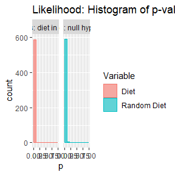

```r
df <- rbind(data.frame(experiment='p-values: diet in data set', p=pvals.data.obs, Variable="Diet"),
            data.frame(experiment='p-values: null hypothesis', p=pvals.null.obs, Variable="Random Diet"))
ggplot(df, aes(x=p, color=Variable, fill=Variable)) + geom_histogram(alpha=0.6, breaks = seq(0,1,0.1)) + facet_wrap(~experiment) +
  ggtitle("Likelihood: Histogram of p-values")
```

PRR test:

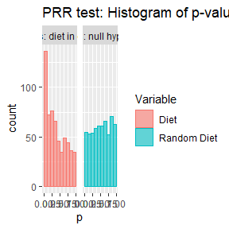

```r
df <- rbind(data.frame(experiment='p-values: diet in data set', p=pvals.data.sim, Variable="Diet"),
            data.frame(experiment='p-values: null hypothesis', p=pvals.null.sim, Variable="Random Diet"))
ggplot(df, aes(x=p, color=Variable, fill=Variable)) + geom_histogram(alpha=0.6, breaks = seq(0,1,0.1)) + facet_wrap(~experiment) +
  ggtitle("PRR test: Histogram of p-values")
```

## New PRR-test implementation for any model (with zero-inflation)

### Test and illustrate implementation

Test the part of the function that splits the data into two model matrices, xyz=TRUE means to return the implicit model matrix 1) X: the count model matrix (before ‘|’ in formula) 2) Z: the zero-inflation model matrix (after ‘|’ in formula)

```r
formula = ASV159 ~ Diet + Age + UrbanizationLevel + Gender + offset(log(library_size)) | Diet + Age + offset(log(library_size))
data   <- prr.test.new.zeroinfl(formula, otu.counts, test.var="Diet", n.rep=1, xyz=TRUE)$data
data$YX <- with(otu.counts, cbind(ASV159, library_size - ASV159))
str(data)
```

```
#> List of 7
#>  $ X      : num [1:149, 1:7] 1 1 1 1 1 1 1 1 1 1 ...
#>   ..- attr(*, "dimnames")=List of 2
#>   .. ..$ : chr [1:149] "S1" "S10" "S100" "S101" ...
#>   .. ..$ : chr [1:7] "(Intercept)" "Dietfisheater" "Dietvegan" "Dietvegetarian" ...
#>   ..- attr(*, "assign")= int [1:7] 0 1 1 1 2 3 4
#>   ..- attr(*, "contrasts")=List of 2
#>   .. ..$ Diet  : chr "contr.treatment"
#>   .. ..$ Gender: chr "contr.treatment"
#>  $ Z      : num [1:149, 1:5] 1 1 1 1 1 1 1 1 1 1 ...
#>   ..- attr(*, "dimnames")=List of 2
#>   .. ..$ : chr [1:149] "S1" "S10" "S100" "S101" ...
#>   .. ..$ : chr [1:5] "(Intercept)" "Dietfisheater" "Dietvegan" "Dietvegetarian" ...
#>   ..- attr(*, "assign")= int [1:5] 0 1 1 1 2
#>   ..- attr(*, "contrasts")=List of 1
#>   .. ..$ Diet: chr "contr.treatment"
#>  $ Y      : Named num [1:149] 80 15 103 0 23 28 91 137 141 15 ...
#>   ..- attr(*, "names")= chr [1:149] "S1" "S10" "S100" "S101" ...
#>  $ offsetx: num [1:149] 11.2 10.9 11.1 10.8 10.4 ...
#>  $ offsetz: num [1:149] 11.2 10.9 11.1 10.8 10.4 ...
#>  $ weights: Named num [1:149] 1 1 1 1 1 1 1 1 1 1 ...
#>   ..- attr(*, "names")= chr [1:149] "S1" "S10" "S100" "S101" ...
#>  $ YX     : num [1:149, 1:2] 80 15 103 0 23 28 91 137 141 15 ...
#>   ..- attr(*, "dimnames")=List of 2
#>   .. ..$ : NULL
#>   .. ..$ : chr [1:2] "ASV159" ""
```

Test the part of the function that fits an arbitrary distribution to data:

```r
for (dist in c("negbin", "zipoisson", "zinegbin", "betabin", "zibinomial", "zibetabin")) {
  Y <- if (dist %in% c("betabin", "zibinomial", "zibetabin")) data$YX else data$Y
  fit <- fitdist(data$X, Y, data$Z, 0, 0, data$weights, dist=dist, control=fitdist.control(trace=F))
  print(dist)
  print(fit$loglik)
}
```

```
#> [1] "negbin"
#> [1] -761.737
#> [1] "zipoisson"
#> [1] -3973.347
#> [1] "zinegbin"
#> [1] -721.3019
#> [1] "betabin"
#> [1] -745.5902
#> [1] "zibinomial"
#> [1] -3174.943
#> [1] "zibetabin"
#> [1] -708.5705
```

Test the whole function that does the permutation test…

Apply a standard Negative Binomial distribution to the data and test for significance of Diet:

```r
formula = ASV159 ~ Diet + Age + UrbanizationLevel + Gender + offset(log(library_size))
prr.test.new.zeroinfl(formula, otu.counts, test.var="Diet", n.rep=1000, dist="negbin")
```

```
#> $p.value.obs
#> [1] 0.005285936
#>
#> $p.value.sim
#> [1] 0
```

Apply a zero-inflated Negative Binomial distribution to the data and test for significance of Diet in both (count, zero) components simultaneously:

```r
formula = ASV159 ~ Diet + Age + UrbanizationLevel + Gender + offset(log(library_size)) | Diet + Age + offset(log(library_size))
prr.test.new.zeroinfl(formula, otu.counts, test.var="Diet", test="both", n.rep=1000, dist="zinegbin")
```

```
#> $p.value.obs
#> [1] 8.674702e-05
#>
#> $p.value.sim
#> [1] 0
```

Apply a zero-inflated Negative Binomial distribution to the data and test for significance of Diet in count component assuming a given model for zeros:

```r
formula = ASV159 ~ Diet + Age + UrbanizationLevel + Gender + offset(log(library_size)) | Diet + Age + offset(log(library_size))
prr.test.new.zeroinfl(formula, otu.counts, test.var="Diet", test="count", n.rep=1000, dist="zinegbin")
```

```
#> $p.value.obs
#> [1] 9.744612e-05
#>
#> $p.value.sim
#> [1] 0
```

Apply a zero-inflated Negative Binomial distribution to the data and test for significance of Diet in zero component assuming a given model for counts:

```r
formula = ASV159 ~ Diet + Age + UrbanizationLevel + Gender + offset(log(library_size)) | Diet + Age + offset(log(library_size))
prr.test.new.zeroinfl(formula, otu.counts, test.var="Diet", test="zero", n.rep=1000, dist="zinegbin")
```

```
#> $p.value.obs
#> [1] 0.07911633
#>
#> $p.value.sim
#> [1] 0.093
```

### Zero-inflated Negative Binomial

This is a standard negative binomial model:

```r
formula = ASV159 ~ Diet + Age + UrbanizationLevel + Gender + Education + PetAnimals + TravelToSE + offset(log(library_size))
prr.test.new.zeroinfl(formula, otu.counts, test.var="Diet", n.rep=1000, dist="negbin")
```

```
#> $p.value.obs
#> [1] 0.007071046
#>
#> $p.value.sim
#> [1] 0
```

The zero-inflated negative binomial often provides a better fit, we could be interested in just the count component…

```r
formula = ASV159 ~ Diet + Age + UrbanizationLevel + Gender + Education + PetAnimals + TravelToSE + offset(log(library_size)) | offset(log(library_size))
prr.test.new.zeroinfl(formula, otu.counts, test.var="Diet", test="count", n.rep=1000, dist="zinegbin")
```

```
#> $p.value.obs
#> [1] 0.0001493719
#>
#> $p.value.sim
#> [1] 0
```

… or both components simultaneously:

```r
formula = ASV159 ~ Diet + Age + UrbanizationLevel + Gender + Education + PetAnimals + TravelToSE + offset(log(library_size)) | Diet + Age + offset(log(library_size))
prr.test.new.zeroinfl(formula, otu.counts, test.var="Diet", test="both", n.rep=1000, dist="zinegbin")
```

```
#> $p.value.obs
#> [1] 0.0001364092
#>
#> $p.value.sim
#> [1] 0
```

Apply the new glmperm implementation all OTUs, saving the likelihood and PRR test based p-values for Diet and DietRandom:

```r
set.seed(42)

pvals.data.obs  <- c()
pvals.null.obs  <- c()
pvals.data.sim  <- c()
pvals.null.sim  <- c()
for(taxa in taxas) {
  eq1 <- as.formula(sprintf("%s ~ Diet + Age + UrbanizationLevel + Gender + Education + PetAnimals + TravelToSE + offset(log(library_size)) | Diet + Age + offset(log(library_size)) ", taxa))
  eq2 <- as.formula(sprintf("%s ~ DietRandom + Age + UrbanizationLevel + Gender + Education + PetAnimals + TravelToSE + offset(log(library_size)) | DietRandom + Age + offset(log(library_size)) ", taxa))
  fit1 <- prr.test.new.zeroinfl(eq1, otu.counts, test.var = "Diet", test="both", n.rep=100, dist="zinegbin")
  fit2 <- prr.test.new.zeroinfl(eq2, otu.counts, test.var = "DietRandom", test="both", n.rep=100, dist="zinegbin")
  pvals.data.obs[taxa]  <- fit1$p.value.obs
  pvals.null.obs[taxa]  <- fit2$p.value.obs
  pvals.data.sim[taxa]  <- fit1$p.value.sim
  pvals.null.sim[taxa]  <- fit2$p.value.sim
}
```

Likelihood:

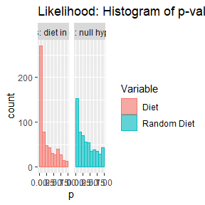

```r
df <- rbind(data.frame(experiment='p-values: diet in data set', p=pvals.data.obs, Variable="Diet"),
            data.frame(experiment='p-values: null hypothesis', p=pvals.null.obs, Variable="Random Diet"))
ggplot(df, aes(x=p, color=Variable, fill=Variable)) + geom_histogram(alpha=0.6, breaks = seq(0,1,0.1)) + facet_wrap(~experiment) +
  ggtitle("Likelihood: Histogram of p-values")
```

PRR test:

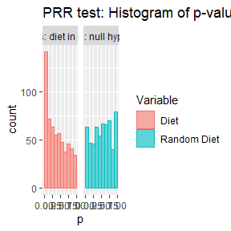

```r
df <- rbind(data.frame(experiment='p-values: diet in data set', p=pvals.data.sim, Variable="Diet"),
            data.frame(experiment='p-values: null hypothesis', p=pvals.null.sim, Variable="Random Diet"))
ggplot(df, aes(x=p, color=Variable, fill=Variable)) + geom_histogram(alpha=0.6, breaks = seq(0,1,0.1)) + facet_wrap(~experiment) +
  ggtitle("PRR test: Histogram of p-values")
```